# Notebook

Last modified

Sep, 2025

23

04:04:09 PM

Comparing Pitch Trackers

praat-parselmouth; pyreaper; librosa; pyworld; libtsm;

# Quest

1. Which python libraries are used for pitch tracking?
2. How long do they take to compute pitch?
3. How well they perform in their default settings?
4. What user-controls do they provide?
5. How to choose the right one for your task?

# Author(s)

Ankit Anand

# Python Libraries for F0 Tracking

Below is a list of tools available to extract pitch of an audio signal.

- Praat with Parselmouth as a python wrapper.
- Pyworld
- Librosa
- Pyreaper

# Execution Time Measurement

We first try to test how different pitch trackers perform in their default settings. It is an uncontrolled experiment where we take an example audio without its ground truth f0 contour for comparison. The idea is to make some visual observations.

```python
#Helper Method
import parselmouth as pm
import pyworld as pw
import pyreaper as pr
import librosa as lb

import numpy as np
import modusa as ms
import time
import pandas as pd



def get_f0_contour(y, sr, lib):
    """
    Compute the F0 contour using different
    python libraries in their default
    settings.

    Parameters
    ----------
    y: ndarray
        Audio signal to compute the F0 contour of.
    sr: int
        Sampling rate of the audio signal.
    lib: str
        Which library to use for computing F0 contour.
        "pm" for parselmouth, "pw" for pyworld, "lr" for librosa, "pr" for pyreaper

    Returns
    -------
    ndarray
        F0 contour.
    ndarray
        time stamps.
    """

    # Parselmouth
    def f0_pm():
        snd = pm.Sound(values=y, sampling_frequency=sr)
        pitch_obj = snd.to_pitch_ac()
        f0 = pitch_obj.selected_array['frequency']
        t = pitch_obj.ts()

        return f0, t

    # Pyworld
    def f0_pw():
        _f0, t = pw.dio(y, sr)
        f0 = pw.stonemask(y, _f0, t, sr) # This is for refining pitch

        return f0, t

    # Librosa
    def f0_lr():
        f0, _, _ = lb.pyin(y=y, sr=sr, fmin=lb.note_to_hz('C2'), fmax=lb.note_to_hz('C7')) # Recommended parameter choice (check docstr)
        t = lb.times_like(f0, sr=sr)

        return f0, t

    # Pyreaper
    def f0_pr():
        y_int = (y * 32767).astype(np.int16)
        _, _, t, f0, _ = pr.reaper(x=y_int, fs=sr)

        return f0, t


    dispatcher = {
        "pm": f0_pm,
        "pw": f0_pw,
        "lr": f0_lr,
        "pr": f0_pr
    }

    if lib not in dispatcher:
        raise ValueError(f"Invalid lib keyword, choose from {dispatcher.keys}")

    # Print the time taken
    tic = time.time()
    f0, f0_t = dispatcher[lib]()
    toc = time.time()
    runtime = toc - tic # Seconds

    return f0, f0_t, runtime

# Load a sample audio signal
def test_time_complexity(dur):
    """
    To test the how long different tools
    take to compute the pitch of an audio
    signal of duration `dur` seconds

    Parameters
    ----------
    dur: float
        - Duration (sec) of the audio to load for testing the tools.

    Returns
    -------
    tuple:
        Duration of the loaded audio signal, Execution time for Praat Parselmouth, Pyworld Dio, Librosa pYIN, Pyreaper in seconds.
    """

    y, sr, title = ms.load("../../../data/fsm-snd/Crocodile 1.mp3", sr=16000, clip=dur)
    ann = ms.load_ann("../../../data/fsm-snd/Crocodile 1-words.txt") # Loading word-level annotation (manually annotated)

    f0_pm, t_pm, pm_runtime = get_f0_contour(y=y, sr=sr, lib="pm") # Parselmouth
    f0_pw, t_pw, pw_runtime = get_f0_contour(y=y, sr=sr, lib="pw") # Pyworld
    f0_lr, t_lr, lr_runtime = get_f0_contour(y=y, sr=sr, lib="lr") # Librosa
    f0_pr, t_pr, pr_runtime = get_f0_contour(y=y, sr=sr, lib="pr") # Pyreaper

    return (y.size / sr, pm_runtime, pw_runtime, lr_runtime, pr_runtime)
```

```python
runtime_df = pd.DataFrame(columns=["Audio Duration", "Praat Parselmouth", "Pyworld Dio", "Librosa pYIN", "Pyreaper"])

durs = [1, 2, 4, 8, 16, 32, 40] # We will test for audio of these duration (seconds)
for dur in durs:
    print(".", end="")
    result = test_time_complexity(dur) # Duration of the loaded audio signal, Execution time for Praat Parselmouth, Pyworld Dio, Librosa pYIN, Pyreaper in seconds
    runtime_df.loc[len(runtime_df)] = result
```

```
.......
```

|  | Audio Duration | Praat Parselmouth | Pyworld Dio | Librosa pYIN | Pyreaper |
| --- | --- | --- | --- | --- | --- |
| 0 | 1.0 | 0.001303 | 0.010937 | 0.361151 | 0.034481 |
| 1 | 2.0 | 0.001792 | 0.018865 | 0.640275 | 0.062411 |
| 2 | 4.0 | 0.004117 | 0.023139 | 1.205628 | 0.133990 |
| 3 | 8.0 | 0.006933 | 0.048849 | 2.291523 | 0.479647 |
| 4 | 16.0 | 0.012203 | 0.106203 | 4.514690 | 0.764026 |
| 5 | 32.0 | 0.024882 | 0.253275 | 9.192464 | 2.313591 |
| 6 | 40.0 | 0.030667 | 0.495712 | 11.232334 | 3.590014 |

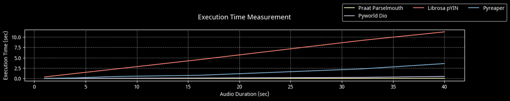

```python
fig = ms.fig("s")
fig.add_signal(runtime_df['Praat Parselmouth'], runtime_df['Audio Duration'], label="Praat Parselmouth", ax=1)
fig.add_signal(runtime_df['Pyworld Dio'], runtime_df['Audio Duration'], label="Pyworld Dio", ax=1)
fig.add_signal(runtime_df['Librosa pYIN'], runtime_df['Audio Duration'], label="Librosa pYIN", ax=1)
fig.add_signal(runtime_df['Pyreaper'], runtime_df['Audio Duration'], label="Pyreaper", ax=1, ylabel="Execution Time (sec)")
fig.add_xlabel("Audio Duration (sec)")
fig.add_title("Execution Time Measurement")
fig.add_legend(1.2)

runtime_df
```

# Performance in Default Settings

While it's important to fine-tune the parameters of these tools depending on the type of audio signals, for now, let's try them with the default settings to see how they perform. We've already computed the result for an audio signal above so let’s examine the contour and make some observations.

```python
y, sr, title = ms.load("../../../data/fsm-snd/Crocodile 1.mp3", sr=16000)
ann = ms.load_ann("../../../data/fsm-snd/Crocodile 1-words.txt") # Loading word-level annotation (manually annotated)

print(f"The duration of the audio track is {y.size / sr :.2f} sec")
```

```
The duration of the audio track is 41.01 sec
```

```python
f0_pm, t_pm, runtime = get_f0_contour(y=y, sr=sr, lib="pm") # Parselmouth
f0_pw, t_pw, runtime = get_f0_contour(y=y, sr=sr, lib="pw") # Pyworld
f0_lr, t_lr, runtime = get_f0_contour(y=y, sr=sr, lib="lr") # Librosa
f0_pr, t_pr, runtime = get_f0_contour(y=y, sr=sr, lib="pr") # Pyreaper
```

```python
# To better observe how these pitch trackers perform, we also look at the spectrogram
N, H = 1024, 160 # 64 ms, 10 ms
S = lb.stft(y, n_fft=N, win_length=N, hop_length=H)
S = np.log(1 + 10*(np.abs(S)**2))
S_f = np.arange(S.shape[0]) * (sr / N)
S_t = np.arange(S.shape[1]) * (H / sr)
```

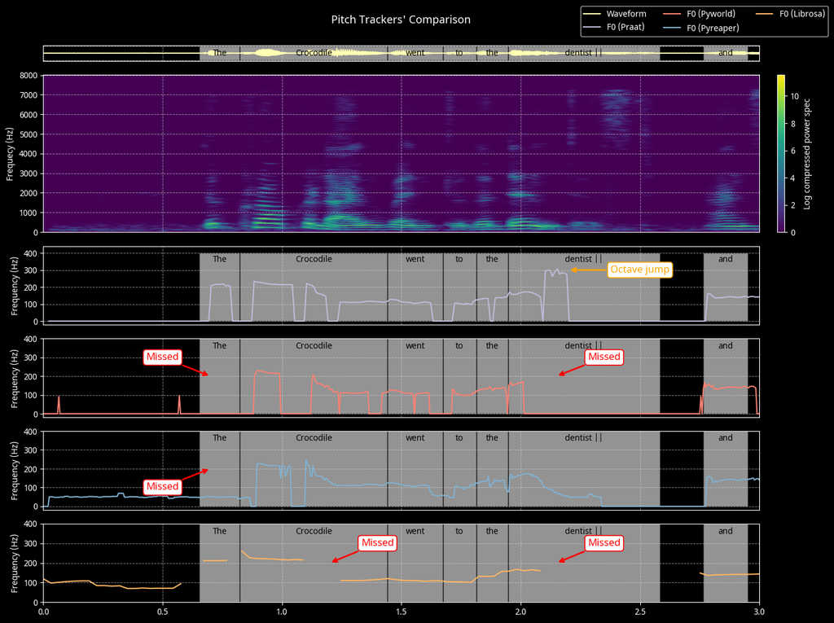

```python
# Visualization
f0_yticks = np.arange(0, 401, 100)
fig = ms.fig("amssss", xlim=(0, 3), dark_mode=True)
fig.add_annotation(ann, ylim=(-1, 1))
fig.add_signal(y, np.arange(y.size) / sr, label="Waveform", ax=1)
fig.add_matrix(S, S_f, S_t, o="lower", ylabel="Frequecy (Hz)", label="Log compressed power spec", ax=2)

fig.add_signal(f0_pm, t_pm, label="F0 (Praat)", ylabel="Frequency (Hz)", yticks=f0_yticks, ax=3)
fig.add_annotation(ann, ylim=(0, 400), text_loc="upper", ax=3)
fig.add_arrows([(2.2, 300)], labels="Octave jump", c="orange", ax=3, text_offset=(0.3, 0))


fig.add_signal(f0_pw, t_pw, label="F0 (Pyworld)", ylabel="Frequency (Hz)", yticks=f0_yticks, ax=4)
fig.add_annotation(ann, ylim=(0, 400), text_loc="upper", ax=4)
fig.add_arrows([(0.7, 200), (2.15, 200)], labels="Missed", c="red", ax=4, text_offset=[(-0.2, 100), (0.2, 100)])

fig.add_signal(f0_pr, t_pr, label="F0 (Pyreaper)", ylabel="Frequency (Hz)", yticks=f0_yticks, ax=5)
fig.add_annotation(ann, ylim=(0, 400), text_loc="upper", ax=5)
fig.add_arrows([(0.7, 200)], labels="Missed", c="red", ax=5, text_offset=(-0.2, -100))


fig.add_signal(f0_lr, t_lr, label="F0 (Librosa)", ylabel="Frequency (Hz)", yticks=f0_yticks, ax=6)
fig.add_annotation(ann, ylim=(0, 400), text_loc="upper", ax=6)
fig.add_arrows([(1.2, 200), (2.15, 200)], labels="Missed", c="red", ax=6, text_offset=(0.2, 100))


fig.add_title("Pitch Trackers' Comparison")
fig.add_legend(0.92)
```

Please note that the observations below are specific to the audio file that we happen to choose randomly:

1. Praat-parselmouth gives us promising results compared to other tools.
2. Pyreaper and Librosa are more sensitive towards giving non-zero values in unvoiced regions.
3. Pyreaper is resistant towards big sudden jumps and thus prevent octave jumps around 2.2 sec.

# User-Controls

- Praat-Parselmouth:
  - time_step:
  - pitch_floor: 75.0
  - max_number_of_candidates: 15
  - very_accurate: True
  - silence_threshold: 0.04
  - voicing_threshold: 0.1
  - octave_cost: 0.05
  - octave_jump_cost: 0.8
  - voiced_unvoiced_cost: 0.6
  - pitch_ceiling: 600